# 16S rRNA Microbiome Data Analysis Workflow

Irene Yang

4/2/2018

### Load packages

```r
library(dada2); packageVersion("dada2")
```

```
## [1] '1.6.0'
```

```r
library(ShortRead); packageVersion("ShortRead")
```

```
## [1] '1.36.1'
```

```r
library(phyloseq); packageVersion("phyloseq")
```

```
## [1] '1.22.3'
```

```r
library(ggplot2); packageVersion("ggplot2")
```

```
## [1] '2.2.1'
```

```r
library(DESeq2)
```

### Change the path to location of files.

```r
# Set path to the sequence data files

path <- "~/Desktop/N741/2018Week7/Mom_Fastq"

fileNames <- list.files(path)

list.files(path)
```

```
##  [1] "filtered"
##  [2] "gg_13_8_train_set_97.fa"
##  [3] "S0013-0001_S97_L001_R1_001.fastq.gz"
##  [4] "S0013-0001_S97_L001_R2_001.fastq.gz"
##  [5] "S0013-0003_S99_L001_R1_001.fastq.gz"
##  [6] "S0013-0003_S99_L001_R2_001.fastq.gz"
##  [7] "S0013-0005_S101_L001_R1_001.fastq.gz"
##  [8] "S0013-0005_S101_L001_R2_001.fastq.gz"
##  [9] "S0013-0007_S103_L001_R1_001.fastq.gz"
## [10] "S0013-0007_S103_L001_R2_001.fastq.gz"
## [11] "S0013-0009_S105_L001_R1_001.fastq.gz"
## [12] "S0013-0009_S105_L001_R2_001.fastq.gz"
## [13] "S0013-0011_S107_L001_R1_001.fastq.gz"
## [14] "S0013-0011_S107_L001_R2_001.fastq.gz"
## [15] "S0013-0012_S108_L001_R1_001.fastq.gz"
```

[output cut: 55 more lines]

### Read in sample names

Using the `dada2` pipeline, first read in the names of the .fastq files. Then manipulate those names as character variables, using regular expressions to create lists of the forward and reverse read .fastq files in *matched* order.

```r
# Forward and reverse fastq filenames should have format: SAMPLENAME_R1_001.fastq and SAMPLENAME_R2_001.fastq

# Start by reading in the names of the .fastq files

fnFs <- sort(list.files(path, pattern="_R1_001.fastq"))
fnRs <- sort(list.files(path, pattern="_R2_001.fastq", full.names = "TRUE"))

# Extract sample names, assuming filenames have format: SAMPLENAME_XXX.fastq

sample.names <- sapply(strsplit(fnFs, "_"), `[`, 1)

# Specify the full path to the fnFs and fnRs
fnFs <- file.path(path, fnFs)
fnRS <- file.path(path, fnRs)
fnFs[1:3]
```

```
## [1] "~/Desktop/N741/2018Week7/Mom_Fastq/S0013-0001_S97_L001_R1_001.fastq.gz"
## [2] "~/Desktop/N741/2018Week7/Mom_Fastq/S0013-0003_S99_L001_R1_001.fastq.gz"
## [3] "~/Desktop/N741/2018Week7/Mom_Fastq/S0013-0005_S101_L001_R1_001.fastq.gz"
```

```r
fnRS[1:3]
```

```
## [1] "~/Desktop/N741/2018Week7/Mom_Fastq//Users/ireneyang/Desktop/N741/2018Week7/Mom_Fastq/S0013-0001_S97_L001_R2_001.fastq.gz"
## [2] "~/Desktop/N741/2018Week7/Mom_Fastq//Users/ireneyang/Desktop/N741/2018Week7/Mom_Fastq/S0013-0003_S99_L001_R2_001.fastq.gz"
## [3] "~/Desktop/N741/2018Week7/Mom_Fastq//Users/ireneyang/Desktop/N741/2018Week7/Mom_Fastq/S0013-0005_S101_L001_R2_001.fastq.gz"
```

### Generate quality profiles of the reads

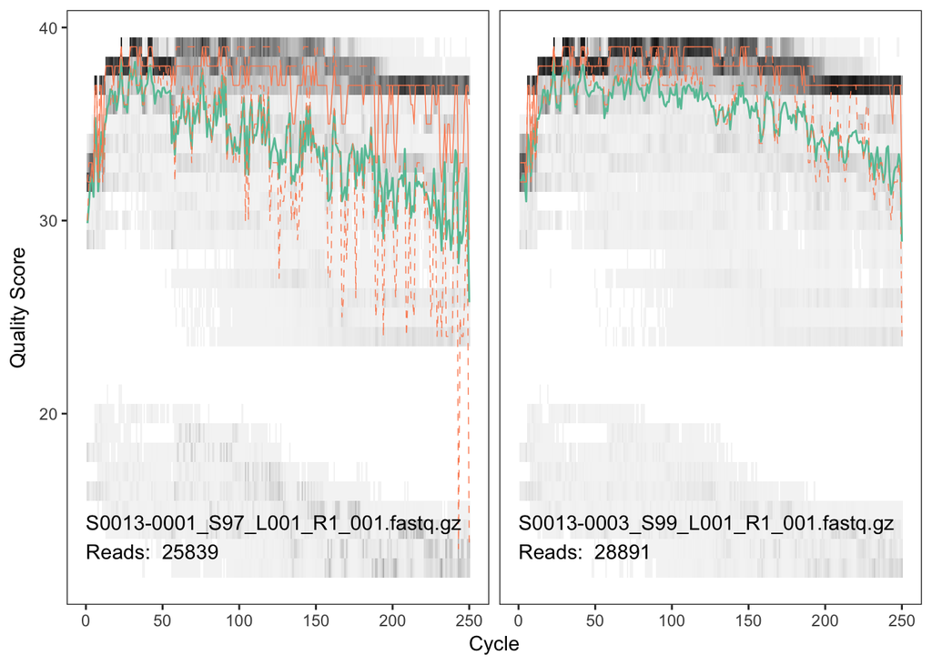

```r
# Visualize the quality profile of the first two files containing forward reads

plotQualityProfile(fnFs[1:2])
```

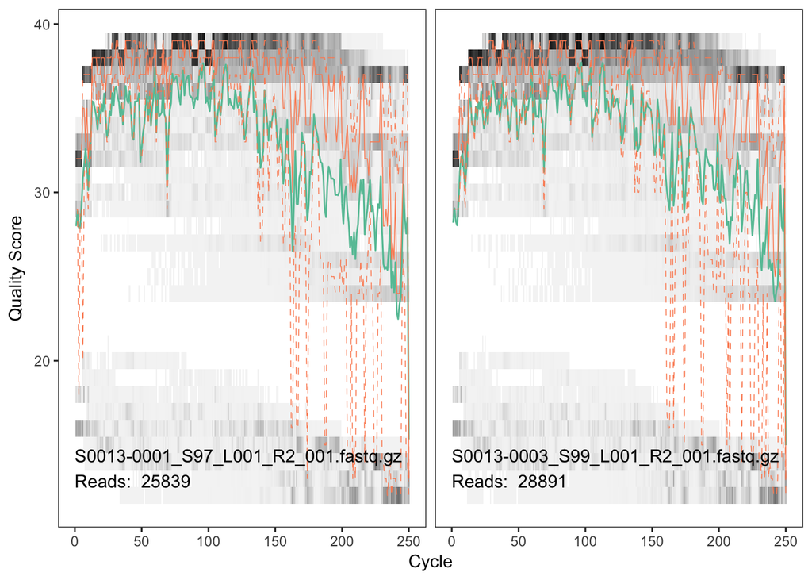

```r
# Visualize the quality profile of the first two files containing reverse reads

plotQualityProfile(fnRs[1:2])
```

### Filter and Trim

Note: Decision made to trim conservatively given the robustness of dada2 to lower quality sequences. Trimmed at 220 (forward) and 180 (reverse). Overlap between forward and reverse reads was ensured.

```r
# Make a directory and filenames for the filtered fastqs

# Place filtered files in a filtered/ subdirectory

filt.path <- file.path(path, "filtered")
if(!file_test("-d", filt.path)) dir.create(filt.path)
filtFs <- file.path(filt.path, paste0(sample.names, "_F_filt.fastq.gz"))
filtRs <- file.path(filt.path, paste0(sample.names, "_R_file.fastq.gz"))

# Filter the forward and reverse reads

out <- filterAndTrim(fnFs, filtFs, fnRs, filtRs, truncLen=c(220,180), maxN=0, maxEE=c(2,5), truncQ = 2, multithread=TRUE, compress=FALSE)

list(out)
```

```
## [[1]]
##                                      reads.in reads.out
## S0013-0001_S97_L001_R1_001.fastq.gz     25839     22137
## S0013-0003_S99_L001_R1_001.fastq.gz     28891     27133
## S0013-0005_S101_L001_R1_001.fastq.gz    22073     19000
## S0013-0007_S103_L001_R1_001.fastq.gz    34091     31992
## S0013-0009_S105_L001_R1_001.fastq.gz     9706      8557
## S0013-0011_S107_L001_R1_001.fastq.gz    11982     10397
## S0013-0012_S108_L001_R1_001.fastq.gz    20093     17884
## S0013-0014_S110_L001_R1_001.fastq.gz    19363     17588
## S0013-0016_S112_L001_R1_001.fastq.gz    28375     26168
## S0013-0018_S114_L001_R1_001.fastq.gz    20817     18801
## S0013-0019_S115_L001_R1_001.fastq.gz    22748     20953
## S0013-0021_S117_L001_R1_001.fastq.gz    16719     15370
## S0013-0022_S118_L001_R1_001.fastq.gz    15828     14196
## S0013-0024_S120_L001_R1_001.fastq.gz    28846     25492
## S0013-0026_S122_L001_R1_001.fastq.gz    14526     12675
## S0013-0027_S123_L001_R1_001.fastq.gz    18119     16864
## S0013-0030_S126_L001_R1_001.fastq.gz    21595     19894
## S0013-0031_S127_L001_R1_001.fastq.gz    23415     21774
## S0013-0033_S129_L001_R1_001.fastq.gz    14185     12981
## S0013-0035_S131_L001_R1_001.fastq.gz    21097     19589
## S0013-0037_S133_L001_R1_001.fastq.gz    15731     14719
## S0013-0039_S135_L001_R1_001.fastq.gz    20753     19353
## S0013-0040_S136_L001_R1_001.fastq.gz    23255     21703
## S0013-0042_S138_L001_R1_001.fastq.gz    21638     20506
## S0013-0043_S139_L001_R1_001.fastq.gz    28106     26008
## S0013-0045_S141_L001_R1_001.fastq.gz     5370      4767
## S0013-0046_S142_L001_R1_001.fastq.gz    26289     24738
## S0013-0048_S144_L001_R1_001.fastq.gz    31033     27790
## S0013-0049_S145_L001_R1_001.fastq.gz    17728     16356
## S0013-0051_S147_L001_R1_001.fastq.gz    29621     28331
## S0013-0052_S148_L001_R1_001.fastq.gz    17043     15849
## S0013-0053_S149_L001_R1_001.fastq.gz    28025     25996
## S0013-0054_S150_L001_R1_001.fastq.gz    24558     22230
## S0013-0055_S151_L001_R1_001.fastq.gz    22675     18878
```

```r
##lenctruncation
```

### Learn the Error Rates

```r
errF <- learnErrors(filtFs, multithread = TRUE)
errR <- learnErrors(filtRs, multithread = TRUE)
```

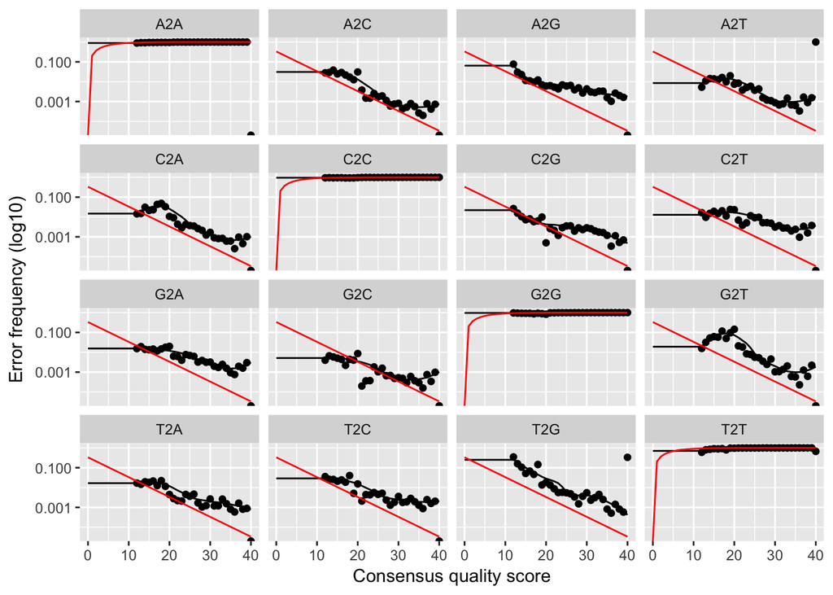

```r
# Visualize the estimated error rates by plotting the forward and reverse reads

plotErrors(errF, nominalQ=TRUE)
```

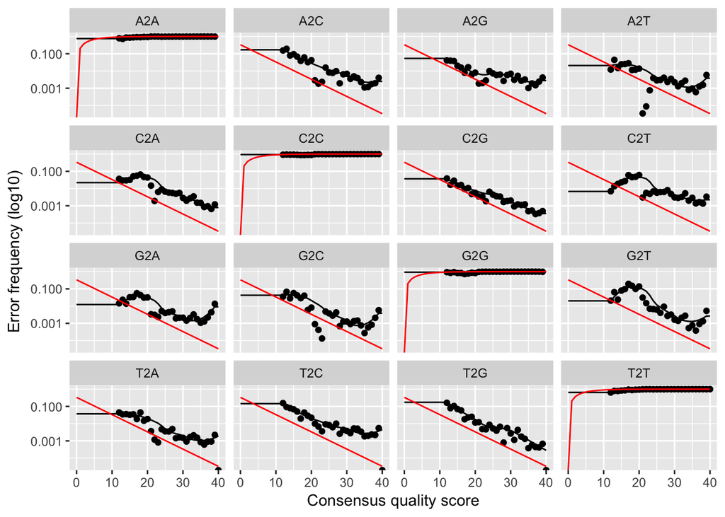

```r
plotErrors(errR, nominalQ = TRUE)
```

### Dereplication

```r
# Dereplicate

derepFs <- derepFastq(filtFs, verbose=TRUE)
derepRs <- derepFastq(filtRs, verbose=TRUE)

# Name the derep-class objects by the sample names

names(derepFs) <- sample.names
names(derepRs) <- sample.names
```

### Sample Inference

Infer the sequence variants in each sample (second dada pass)

```r
# First with the Forward reads

dadaFs <- dada(derepFs, err = errF, multithread = TRUE)

# Then with the Reverse reads

dadaRs <- dada(derepRs, err = errR, multithread = TRUE)
```

```r
# Inspect the dada-class objects returned by the dada function

dadaFs[[1]]
```

```
## dada-class: object describing DADA2 denoising results
## 99 sample sequences were inferred from 5342 input unique sequences.
## Key parameters: OMEGA_A = 1e-40, BAND_SIZE = 16, USE_QUALS = TRUE
```

```r
dadaRs[[1]]
```

```
## dada-class: object describing DADA2 denoising results
## 87 sample sequences were inferred from 6968 input unique sequences.
## Key parameters: OMEGA_A = 1e-40, BAND_SIZE = 16, USE_QUALS = TRUE
```

We can see that the algorithm has inferred 99 unique sequence variants from the forward reads and 87 from the reverse reads.

### Merge Paired Reads

We can eliminate further spurious sequence variants by merging overlapping reads. The core function is `mergePairs` and it depends on the forward and reverse reads being in matching order at the time they were dereplicated.

```r
# Merge the denoised forward and reverse reads

mergers <- mergePairs(dadaFs, derepFs, dadaRs, derepRs, verbose = TRUE )
```

```
## 21299 paired-reads (in 84 unique pairings) successfully merged out of 22137 (in 292 pairings) input.
```

```
## 25590 paired-reads (in 157 unique pairings) successfully merged out of 27133 (in 587 pairings) input.
```

```
## 18261 paired-reads (in 46 unique pairings) successfully merged out of 19000 (in 178 pairings) input.
```

```
## 28591 paired-reads (in 227 unique pairings) successfully merged out of 31992 (in 1139 pairings) input.
```

```
## 8282 paired-reads (in 46 unique pairings) successfully merged out of 8557 (in 119 pairings) input.
```

```
## 9981 paired-reads (in 85 unique pairings) successfully merged out of 10397 (in 199 pairings) input.
```

```
## 16959 paired-reads (in 142 unique pairings) successfully merged out of 17884 (in 443 pairings) input.
```

```
## 16729 paired-reads (in 93 unique pairings) successfully merged out of 17588 (in 318 pairings) input.
```

```
## 24709 paired-reads (in 150 unique pairings) successfully merged out of 26168 (in 527 pairings) input.
```

```
## 18008 paired-reads (in 92 unique pairings) successfully merged out of 18801 (in 273 pairings) input.
```

```
## 19825 paired-reads (in 147 unique pairings) successfully merged out of 20953 (in 509 pairings) input.
```

```
## 14703 paired-reads (in 146 unique pairings) successfully merged out of 15370 (in 366 pairings) input.
```

```
## 13590 paired-reads (in 92 unique pairings) successfully merged out of 14196 (in 239 pairings) input.
```

```
## 24069 paired-reads (in 144 unique pairings) successfully merged out of 25492 (in 594 pairings) input.
```

```
## 12253 paired-reads (in 79 unique pairings) successfully merged out of 12675 (in 199 pairings) input.
```

```
## 16277 paired-reads (in 105 unique pairings) successfully merged out of 16864 (in 279 pairings) input.
```

```
## 18358 paired-reads (in 143 unique pairings) successfully merged out of 19894 (in 563 pairings) input.
```

```
## 20174 paired-reads (in 116 unique pairings) successfully merged out of 21774 (in 488 pairings) input.
```

```
## 11589 paired-reads (in 142 unique pairings) successfully merged out of 12981 (in 620 pairings) input.
```

```
## 17742 paired-reads (in 212 unique pairings) successfully merged out of 19589 (in 799 pairings) input.
```

```
## 13294 paired-reads (in 161 unique pairings) successfully merged out of 14719 (in 612 pairings) input.
```

```
## 17129 paired-reads (in 168 unique pairings) successfully merged out of 19353 (in 712 pairings) input.
```

```
## 20122 paired-reads (in 177 unique pairings) successfully merged out of 21703 (in 663 pairings) input.
```

```
## 18870 paired-reads (in 180 unique pairings) successfully merged out of 20506 (in 677 pairings) input.
```

```
## 23693 paired-reads (in 212 unique pairings) successfully merged out of 26008 (in 867 pairings) input.
```

```
## 4576 paired-reads (in 64 unique pairings) successfully merged out of 4767 (in 116 pairings) input.
```

```
## 23390 paired-reads (in 160 unique pairings) successfully merged out of 24738 (in 605 pairings) input.
```

```
## 26688 paired-reads (in 140 unique pairings) successfully merged out of 27790 (in 454 pairings) input.
```

```
## 15426 paired-reads (in 133 unique pairings) successfully merged out of 16356 (in 347 pairings) input.
```

```
## 26543 paired-reads (in 191 unique pairings) successfully merged out of 28331 (in 741 pairings) input.
```

```
## 14281 paired-reads (in 163 unique pairings) successfully merged out of 15849 (in 649 pairings) input.
```

```
## 24265 paired-reads (in 155 unique pairings) successfully merged out of 25996 (in 689 pairings) input.
```

```
## 20789 paired-reads (in 129 unique pairings) successfully merged out of 22230 (in 528 pairings) input.
```

```
## 18012 paired-reads (in 85 unique pairings) successfully merged out of 18878 (in 325 pairings) input.
```

```r
# Inspect the merged data.frame from the first sample

head(mergers[[1]])
```

```
##                                                                                                                                                                                                                                                         sequence
## 1   TACGTAGGTCCCGAGCGTTGTCCGGATTTATTGGGCGTAAAGCGAGCGCAGGCGGTTAGA…
## 2   TACGTAGGTCCCGAGCGTTGTCCGGATTTATTGGGCGTAAAGCGAGCGCAGGCGGTTAGA…
## 3 TACGTAGGGTGCGAGCGTTGTCCGGAATTACTGGGCGTAAAGAGCTCGTAGGTGGTTTGT…
## 4   TACGTAGGTGGCAAGCGTTGTCCGGAATTATTGGGCGTAAAGCGCGCGCAGGCGGATAGG…
## 5  TACGTAGGGTGCGAGCGTTAATCGGAATTACTGGGCGTAAAGCGGGCGCAGACGGTTACT…
## 6  TACGTAGGGCGCGAGCGTTGTCCGGAATTATTGGGCGTAAAGAGCTCGTAGGCGGCTGGT…
##   abundance forward reverse nmatch nmismatch nindel prefer accept
## 1      3218       3       1    148         0      0      2   TRUE
## 2      2404       4       2    148         0      0      2   TRUE
## 3      2217       1       4    146         0      0      1   TRUE
## 4      2152       2       3    148         0      0      1   TRUE
## 5      1418       5       5    147         0      0      1   TRUE
## 6      1141       7       7    147         0      0      1   TRUE
```

### Sequence Table Construction

We will now construct the sequence table, this being analogous to the “OTU table” produced by other methods.

```r
# Construct sequence table

seqtab <- makeSequenceTable(mergers)
```

```
## The sequences being tabled vary in length.
```

```r
# Consider the table

dim(seqtab)
```

```
## [1]   34 1483
```

```r
class(seqtab)
```

```
## [1] "matrix"
```

```r
# Inspect the distribution of sequence lengths

table(nchar(getSequences(seqtab)))
```

```
##
## 233 234 252 253 254 255 322 338 339
##   1   1 466 970  29  13   1   1   1
```

```r
seqtab2 <- seqtab[,nchar(colnames(seqtab)) %in% seq(250, 256)]

dim(seqtab2)
```

```
## [1]   34 1478
```

```r
class(seqtab2)
```

```
## [1] "matrix"
```

```r
table(nchar(getSequences(seqtab2)))
```

```
##
## 252 253 254 255
## 466 970  29  13
```

### Remove Chimeras

```r
# Remove chimeric sequences

seqtab2.nochim <- removeBimeraDenovo(seqtab2, method = "consensus", multithread = TRUE, verbose=TRUE)
```

```
## Identified 629 bimeras out of 1478 input sequences.
```

```r
dim(seqtab2.nochim)
```

```
## [1]  34 849
```

```r
sum(seqtab2.nochim)/sum(seqtab2)
```

```
## [1] 0.9708215
```

### Track Reads through the Pipeline

```r
getN <- function(x) sum(getUniques(x))
pctSurv <- rowSums(seqtab2.nochim)*100/out[,1]
track <- cbind(out, sapply(dadaFs, getN), sapply(mergers, getN), rowSums(seqtab), rowSums(seqtab2.nochim), pctSurv)
colnames(track) <- c("input", "filtered", "denoised", "merged", "tabled", "nonchimeric", "% passing")
rownames(track) <- sample.names
head(track)
```

```
##            input filtered denoised merged tabled nonchimeric % passing
## S0013-0001 25839    22137    22137  21299  21299       20451  79.14780
## S0013-0003 28891    27133    27133  25590  25590       23849  82.54820
## S0013-0005 22073    19000    19000  18261  18261       17726  80.30626
## S0013-0007 34091    31992    31992  28591  28591       27427  80.45232
## S0013-0009  9706     8557     8557   8282   8282        8282  85.32866
## S0013-0011 11982    10397    10397   9981   9981        9978  83.27491
```

```r
#Calculate average of nonchimeric reads per sample
mean(track[,"nonchimeric"])
```

```
## [1] 17819.03
```

### Assign Taxonomy

GreenGenes 13_8 reference will be used.

```r
# Assign taxonomy

# First initialize random number generator for reproducibility

set.seed(100)
getwd()
```

```
## [1] "/Users/ireneyang/Desktop/N741/Final-Project/Milestone 3"
```

```r
path
```

```
## [1] "~/Desktop/N741/2018Week7/Mom_Fastq"
```

```r
# list.files omitted to save space on rmarkdown

taxa <- assignTaxonomy(seqtab2.nochim, "~/Desktop/N741/2018Week7/Mom_Fastq/gg_13_8_train_set_97.fa", multithread = TRUE)
unname(head(taxa))
```

```
##      [,1]          [,2]                [,3]
## [1,] "k__Bacteria" "p__Firmicutes"     "c__Bacilli"
## [2,] "k__Bacteria" "p__Firmicutes"     "c__Clostridia"
## [3,] "k__Bacteria" "p__Actinobacteria" "c__Actinobacteria"
## [4,] "k__Bacteria" "p__Actinobacteria" "c__Actinobacteria"
## [5,] "k__Bacteria" "p__Fusobacteria"   "c__Fusobacteriia"
## [6,] "k__Bacteria" "p__Proteobacteria" "c__Gammaproteobacteria"
##      [,4]                 [,5]                    [,6]
## [1,] "o__Lactobacillales" "f__Streptococcaceae"   "g__Streptococcus"
## [2,] "o__Clostridiales"   "f__Veillonellaceae"    "g__Veillonella"
## [3,] "o__Actinomycetales" "f__Corynebacteriaceae" "g__Corynebacterium"
## [4,] "o__Actinomycetales" "f__Actinomycetaceae"   "g__Actinomyces"
## [5,] "o__Fusobacteriales" "f__Fusobacteriaceae"   "g__Fusobacterium"
## [6,] "o__Pasteurellales"  "f__Pasteurellaceae"    "g__Haemophilus"
##      [,7]
## [1,] "s__"
## [2,] "s__dispar"
## [3,] "s__"
## [4,] "s__"
## [5,] "s__"
## [6,] "s__parainfluenzae"
```

Inspect the taxonomic assignments:

```r
taxa.print <- taxa #Removing sequence rownames for display only
rownames (taxa.print) <- NULL
head(taxa.print)
```

```
##      Kingdom       Phylum              Class
## [1,] "k__Bacteria" "p__Firmicutes"     "c__Bacilli"
## [2,] "k__Bacteria" "p__Firmicutes"     "c__Clostridia"
## [3,] "k__Bacteria" "p__Actinobacteria" "c__Actinobacteria"
## [4,] "k__Bacteria" "p__Actinobacteria" "c__Actinobacteria"
## [5,] "k__Bacteria" "p__Fusobacteria"   "c__Fusobacteriia"
## [6,] "k__Bacteria" "p__Proteobacteria" "c__Gammaproteobacteria"
##      Order                Family                  Genus
## [1,] "o__Lactobacillales" "f__Streptococcaceae"   "g__Streptococcus"
## [2,] "o__Clostridiales"   "f__Veillonellaceae"    "g__Veillonella"
## [3,] "o__Actinomycetales" "f__Corynebacteriaceae" "g__Corynebacterium"
## [4,] "o__Actinomycetales" "f__Actinomycetaceae"   "g__Actinomyces"
## [5,] "o__Fusobacteriales" "f__Fusobacteriaceae"   "g__Fusobacterium"
## [6,] "o__Pasteurellales"  "f__Pasteurellaceae"    "g__Haemophilus"
##      Species
## [1,] "s__"
## [2,] "s__dispar"
## [3,] "s__"
## [4,] "s__"
## [5,] "s__"
## [6,] "s__parainfluenzae"
```

### Construct a Phylogenetic Tree

```r
library(DECIPHER)
seqs <- getSequences(seqtab2.nochim)

# This next command will allow propagation of sequence names to the tip labels of the tree
names(seqs) <- seqs
alignment <- AlignSeqs(DNAStringSet(seqs), anchor=NA)

# Construct tree

library(phangorn)

phang.align <- phyDat(as(alignment, "matrix"), type="DNA")
dm <- dist.ml(phang.align)
treeNJ <- NJ(dm) # Tip order will not equal sequence order
fit <- pml(treeNJ, data=phang.align)

## negative edges length changed to 0.

fitGTR <- update(fit, k=4, inv=0.2)
fitGTR <- optim.pml(fitGTR, model="GTR", optInv=TRUE, optGamma=TRUE,
                    rearrangement = "stochastic", control=pml.control(trace=0))
detach("package:phangorn", unload=TRUE)
```

### Handoff to `phyloseq`

Our next activity will be to hand off the data to the `phyloseq` package for analysis. This package requires three items: the “OTUtable,” the taxonomy table, and data about the samples. The first two items are directly available at the end of your `dada2`run, and you can import the latter as a .csv file.

```r
# Import metadata file.

samdf <- read.csv("~/Desktop/N741/2018Week7/Mom_Metadata.csv",header=TRUE)

rownames(samdf) <- samdf$Sample_ID

rownames(samdf)
```

```
##  [1] "S0013-0001" "S0013-0003" "S0013-0005" "S0013-0007" "S0013-0009"
##  [6] "S0013-0011" "S0013-0012" "S0013-0014" "S0013-0016" "S0013-0018"
## [11] "S0013-0019" "S0013-0021" "S0013-0022" "S0013-0024" "S0013-0026"
## [16] "S0013-0027" "S0013-0030" "S0013-0031" "S0013-0033" "S0013-0035"
## [21] "S0013-0037" "S0013-0039" "S0013-0040" "S0013-0042" "S0013-0043"
## [26] "S0013-0045" "S0013-0046" "S0013-0048" "S0013-0049" "S0013-0051"
## [31] "S0013-0052" "S0013-0053" "S0013-0054" "S0013-0055"
```

```r
rownames(seqtab2.nochim)
```

```
##  [1] "S0013-0001" "S0013-0003" "S0013-0005" "S0013-0007" "S0013-0009"
##  [6] "S0013-0011" "S0013-0012" "S0013-0014" "S0013-0016" "S0013-0018"
## [11] "S0013-0019" "S0013-0021" "S0013-0022" "S0013-0024" "S0013-0026"
## [16] "S0013-0027" "S0013-0030" "S0013-0031" "S0013-0033" "S0013-0035"
## [21] "S0013-0037" "S0013-0039" "S0013-0040" "S0013-0042" "S0013-0043"
## [26] "S0013-0045" "S0013-0046" "S0013-0048" "S0013-0049" "S0013-0051"
## [31] "S0013-0052" "S0013-0053" "S0013-0054" "S0013-0055"
```

Create the phyloseq object.

```r
library(phyloseq)

# Create phyloseq object

ps <- phyloseq(otu_table(seqtab2.nochim, taxa_are_rows=FALSE),
               sample_data(samdf),
               tax_table(taxa),
               phy_tree(fitGTR$tree))

# Describe it

ps
```

```
## phyloseq-class experiment-level object
## otu_table()   OTU Table:         [ 849 taxa and 34 samples ]
## sample_data() Sample Data:       [ 34 samples by 6 sample variables ]
## tax_table()   Taxonomy Table:    [ 849 taxa by 7 taxonomic ranks ]
## phy_tree()    Phylogenetic Tree: [ 849 tips and 847 internal nodes ]
```

### Diversity in Microbial Ecology

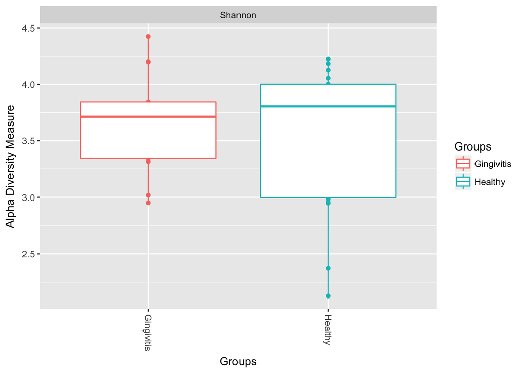

```r
# Plot alpha-diversity

plot_richness(ps, x="Groups", measures = c("Shannon"), color="Groups") + geom_boxplot()
```

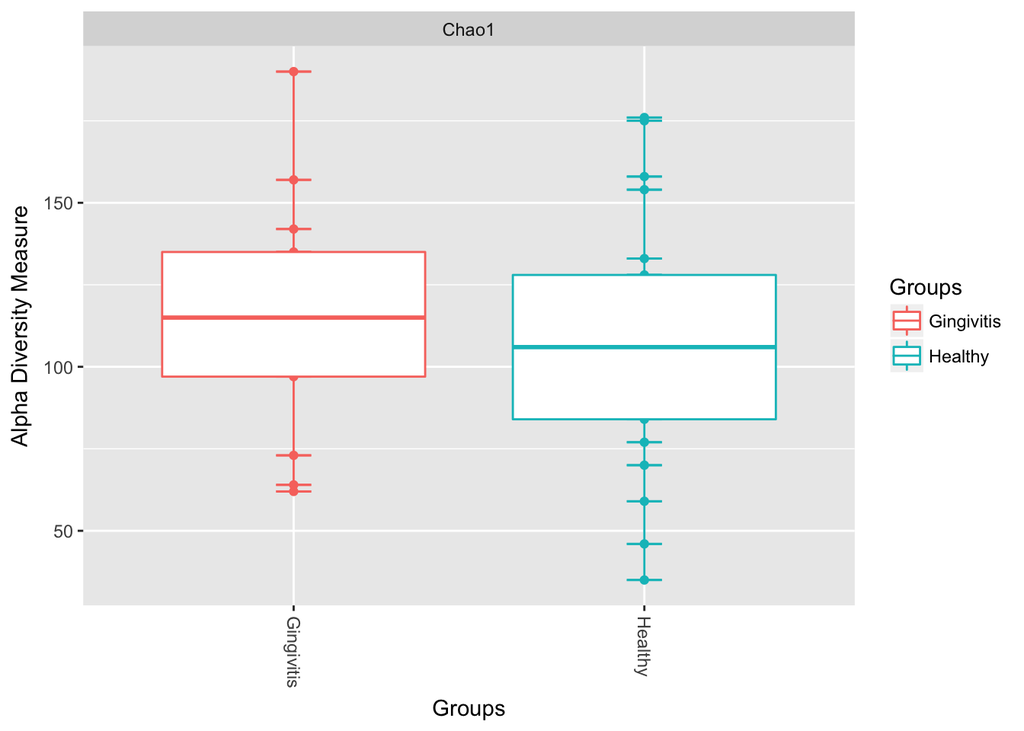

```r
plot_richness(ps, x="Groups", measures = c("Chao1"), color="Groups") + geom_boxplot()
```

### Ordinate

Using the Bray-Curtis dissimilarity index.

```r
# Ordinate with Bray-Curtis

ord.nmds.bray <- ordinate(ps, method="NMDS", distance="bray")
```

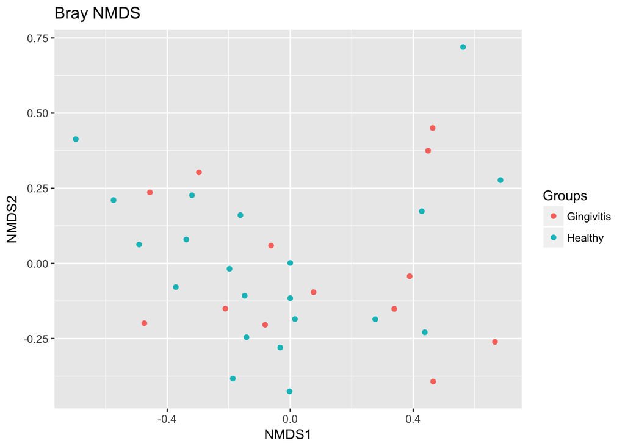

```r
plot_ordination(ps, ord.nmds.bray, color="Groups", title="Bray NMDS")
```

### Bar Plots

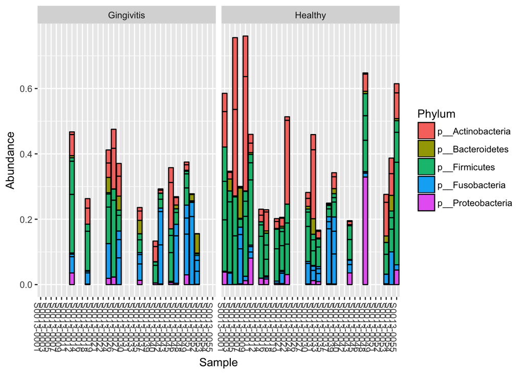

```r
# Create bar plots for top 10 OTUs

top10 <- names(sort(taxa_sums(ps), decreasing = TRUE))[1:10]
ps.top10 <- transform_sample_counts(ps, function(OTU) OTU/sum(OTU))
ps.top10 <- prune_taxa(top10, ps.top10)

plot_bar(ps.top10, fill="Phylum", facet_grid=~Groups)
```

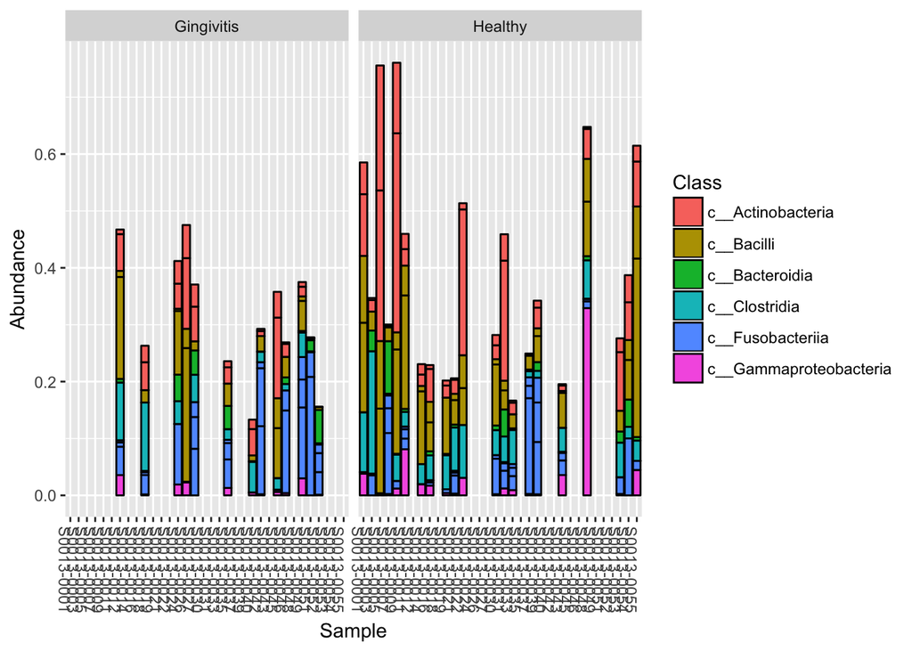

```r
plot_bar(ps.top10, fill="Class", facet_grid=~Groups)
```

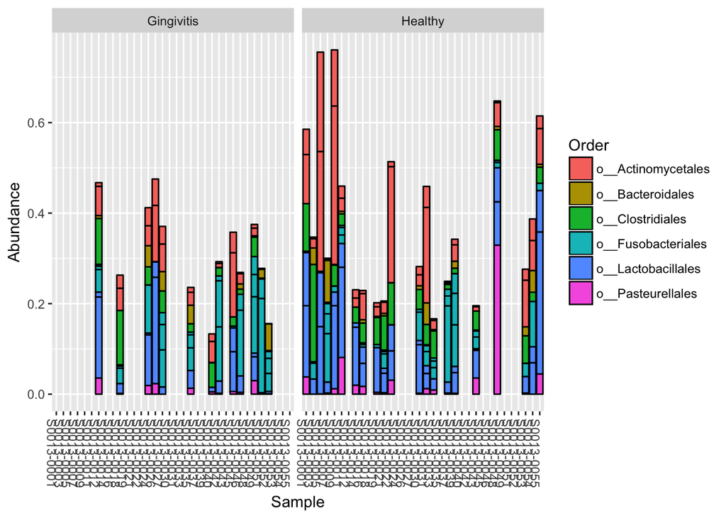

```r
plot_bar(ps.top10, fill="Order", facet_grid=~Groups)
```

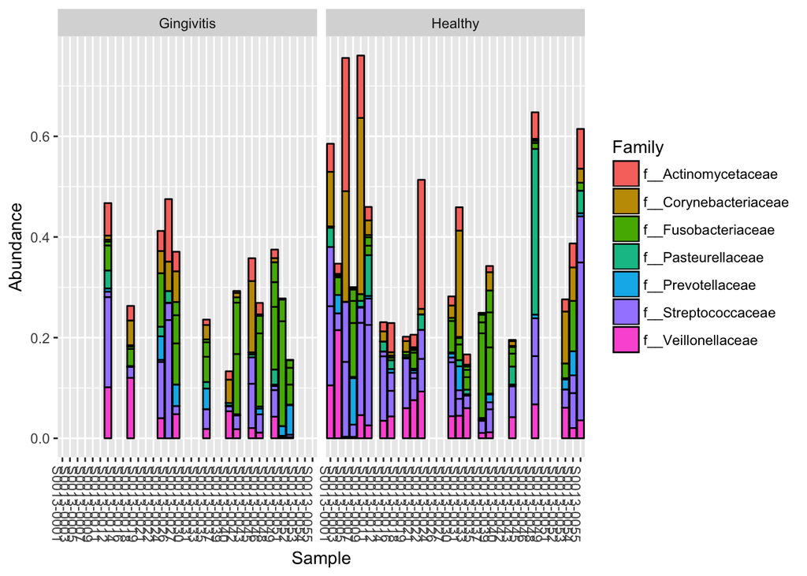

```r
plot_bar(ps.top10, fill="Family", facet_grid=~Groups)
```

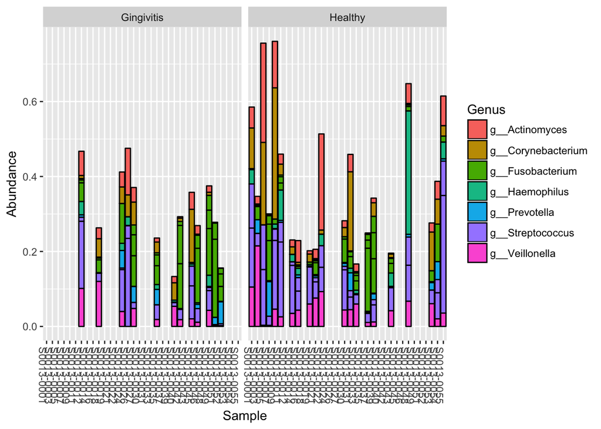

```r
plot_bar(ps.top10, fill="Genus", facet_grid=~Groups)
```

### Differential Abundance Testing

```r
#Differential abundance testing

#First remove samples with less than 500 reads (counts). Note that this kind of data cleanup is useful, necessary, and should be well-documented.

ps <- prune_samples(sample_sums(ps) > 500, ps)
ps
```

```
## phyloseq-class experiment-level object
## otu_table()   OTU Table:         [ 849 taxa and 34 samples ]
## sample_data() Sample Data:       [ 34 samples by 6 sample variables ]
## tax_table()   Taxonomy Table:    [ 849 taxa by 7 taxonomic ranks ]
## phy_tree()    Phylogenetic Tree: [ 849 tips and 847 internal nodes ]
```

```r
#Perform deseq2 analysis

diagdds = phyloseq_to_deseq2(ps, ~ Groups)
# calculate geometric means prior to estimate size factors
gm_mean = function(x, na.rm=TRUE){
  exp(sum(log(x[x > 0]), na.rm=na.rm) / length(x))
}
geoMeans = apply(counts(diagdds), 1, gm_mean)
diagdds = estimateSizeFactors(diagdds, geoMeans = geoMeans)
diagdds = DESeq(diagdds, fitType="local")
```

```
## -- replacing outliers and refitting for 552 genes
## -- DESeq argument 'minReplicatesForReplace' = 7
## -- original counts are preserved in counts(dds)
```

```r
#Investigate test results table

res = results(diagdds)
res = res[order(res$padj, na.last=NA), ]
alpha = 0.01
sigtab = res[(res$padj < alpha), ]
sigtab = cbind(as(sigtab, "data.frame"), as(tax_table(ps)[rownames(sigtab), ], "matrix"))
head(sigtab)
```

```
##                                                                                                                                                                                                                                                                baseMean
## TACGGAAGGTCCGGGCGTTATCCGGAATTATTGGGTTTAAAGGGAGCGCAGGCGGGAGTA…  15.410865
## TACGTATGTCACGAGCGTTATCCGGATTTATTGGGCGTAAAGCGCGTCTAGGTGGTTATG…  10.220965
## TACGGAAGGTCCGGGCGTTATCCGGATTTATTGGGTTTAAAGGGAGCGTAGGCCGGGGAT…  8.545621
## TACGGAAGGTCCAGGCGTTATCCGGATTTATTGGGTTTAAAGGGAGTGTAGGCGGTCTGT…  6.127893
## TACGGAGGGTGCGAGCGTTAATCGGAATAACTGGGCGTAAAGGGCACGCAGGCGGACTTT…  3.002611
## TACGTAGGGTGCGAGCGTTAATCGGAATTACTGGGCGTAAAGCGGGCGCAGACGGTTACT…  9.062818
##                                                                                                                                                                                                                                                               log2FoldChange
## TACGGAAGGTCCGGGCGTTATCCGGAATTATTGGGTTTAAAGGGAGCGCAGGCGGGAGTA…        22.54428
## TACGTATGTCACGAGCGTTATCCGGATTTATTGGGCGTAAAGCGCGTCTAGGTGGTTATG…       -24.05048
## TACGGAAGGTCCGGGCGTTATCCGGATTTATTGGGTTTAAAGGGAGCGTAGGCCGGGGAT…      -23.80486
## TACGGAAGGTCCAGGCGTTATCCGGATTTATTGGGTTTAAAGGGAGTGTAGGCGGTCTGT…      -23.33284
## TACGGAGGGTGCGAGCGTTAATCGGAATAACTGGGCGTAAAGGGCACGCAGGCGGACTTT…      -22.06164
## TACGTAGGGTGCGAGCGTTAATCGGAATTACTGGGCGTAAAGCGGGCGCAGACGGTTACT…       21.81413
##                                                                                                                                                                                                                                                                  lfcSE
## TACGGAAGGTCCGGGCGTTATCCGGAATTATTGGGTTTAAAGGGAGCGCAGGCGGGAGTA…  2.608775
## TACGTATGTCACGAGCGTTATCCGGATTTATTGGGCGTAAAGCGCGTCTAGGTGGTTATG…  3.002967
## TACGGAAGGTCCGGGCGTTATCCGGATTTATTGGGTTTAAAGGGAGCGTAGGCCGGGGAT… 3.003175
## TACGGAAGGTCCAGGCGTTATCCGGATTTATTGGGTTTAAAGGGAGTGTAGGCGGTCTGT… 3.003678
## TACGGAGGGTGCGAGCGTTAATCGGAATAACTGGGCGTAAAGGGCACGCAGGCGGACTTT… 3.005514
## TACGTAGGGTGCGAGCGTTAATCGGAATTACTGGGCGTAAAGCGGGCGCAGACGGTTACT… 3.023400
##                                                                                                                                                                                                                                                                    stat
## TACGGAAGGTCCGGGCGTTATCCGGAATTATTGGGTTTAAAGGGAGCGCAGGCGGGAGTA…   8.641711
## TACGTATGTCACGAGCGTTATCCGGATTTATTGGGCGTAAAGCGCGTCTAGGTGGTTATG…  -8.008904
## TACGGAAGGTCCGGGCGTTATCCGGATTTATTGGGTTTAAAGGGAGCGTAGGCCGGGGAT… -7.926564
## TACGGAAGGTCCAGGCGTTATCCGGATTTATTGGGTTTAAAGGGAGTGTAGGCGGTCTGT… -7.768091
## TACGGAGGGTGCGAGCGTTAATCGGAATAACTGGGCGTAAAGGGCACGCAGGCGGACTTT… -7.340387
## TACGTAGGGTGCGAGCGTTAATCGGAATTACTGGGCGTAAAGCGGGCGCAGACGGTTACT…  7.215098
##                                                                                                                                                                                                                                                                     pvalue
## TACGGAAGGTCCGGGCGTTATCCGGAATTATTGGGTTTAAAGGGAGCGCAGGCGGGAGTA…  5.537728e-18
## TACGTATGTCACGAGCGTTATCCGGATTTATTGGGCGTAAAGCGCGTCTAGGTGGTTATG…  1.157356e-15
## TACGGAAGGTCCGGGCGTTATCCGGATTTATTGGGTTTAAAGGGAGCGTAGGCCGGGGAT… 2.252923e-15
## TACGGAAGGTCCAGGCGTTATCCGGATTTATTGGGTTTAAAGGGAGTGTAGGCGGTCTGT… 7.967784e-15
## TACGGAGGGTGCGAGCGTTAATCGGAATAACTGGGCGTAAAGGGCACGCAGGCGGACTTT… 2.129763e-13
## TACGTAGGGTGCGAGCGTTAATCGGAATTACTGGGCGTAAAGCGGGCGCAGACGGTTACT… 5.389502e-13
##                                                                                                                                                                                                                                                                       padj
## TACGGAAGGTCCGGGCGTTATCCGGAATTATTGGGTTTAAAGGGAGCGCAGGCGGGAGTA…  3.123279e-15
## TACGTATGTCACGAGCGTTATCCGGATTTATTGGGCGTAAAGCGCGTCTAGGTGGTTATG…  3.263743e-13
## TACGGAAGGTCCGGGCGTTATCCGGATTTATTGGGTTTAAAGGGAGCGTAGGCCGGGGAT… 4.235496e-13
## TACGGAAGGTCCAGGCGTTATCCGGATTTATTGGGTTTAAAGGGAGTGTAGGCGGTCTGT… 1.123458e-12
```

[output cut: 36 more lines]

```
## TACGTAGGGTGCGAGCGTTAATCGGAATTACTGGGCGTAAAGCGGGCGCAGACGGTTACT…        f__Neisseriaceae
##                                                                                                                                                                                                                                                                            Genus
## TACGGAAGGTCCGGGCGTTATCCGGAATTATTGGGTTTAAAGGGAGCGCAGGCGGGAGTA…     g__[Prevotella]
## TACGTATGTCACGAGCGTTATCCGGATTTATTGGGCGTAAAGCGCGTCTAGGTGGTTATG…    g__Fusobacterium
## TACGGAAGGTCCGGGCGTTATCCGGATTTATTGGGTTTAAAGGGAGCGTAGGCCGGGGAT…      g__Prevotella
## TACGGAAGGTCCAGGCGTTATCCGGATTTATTGGGTTTAAAGGGAGTGTAGGCGGTCTGT…      g__Prevotella
## TACGGAGGGTGCGAGCGTTAATCGGAATAACTGGGCGTAAAGGGCACGCAGGCGGACTTT… g__Aggregatibacter
## TACGTAGGGTGCGAGCGTTAATCGGAATTACTGGGCGTAAAGCGGGCGCAGACGGTTACT…       g__Neisseria
##                                                                                                                                                                                                                                                                     Species
## TACGGAAGGTCCGGGCGTTATCCGGAATTATTGGGTTTAAAGGGAGCGCAGGCGGGAGTA…    s__tannerae
## TACGTATGTCACGAGCGTTATCCGGATTTATTGGGCGTAAAGCGCGTCTAGGTGGTTATG…            s__
## TACGGAAGGTCCGGGCGTTATCCGGATTTATTGGGTTTAAAGGGAGCGTAGGCCGGGGAT…           s__
## TACGGAAGGTCCAGGCGTTATCCGGATTTATTGGGTTTAAAGGGAGTGTAGGCGGTCTGT… s__intermedia
## TACGGAGGGTGCGAGCGTTAATCGGAATAACTGGGCGTAAAGGGCACGCAGGCGGACTTT…           s__
## TACGTAGGGTGCGAGCGTTAATCGGAATTACTGGGCGTAAAGCGGGCGCAGACGGTTACT…           s__
```

```r
posigtab = sigtab[sigtab[, "log2FoldChange"] > 0, ]
posigtab = posigtab[, c("baseMean", "log2FoldChange", "lfcSE", "padj", "Phylum", "Class", "Family", "Genus")]
```